# Track 1 Bikes Case Study- July

N. White

January 25, 2022 - January 27, 2022

# Cyclistic Bike Data

### July

```r
Jul <- read_csv("202107-divvy-tripdata.csv")
Jul <- Jul %>%
  mutate(Jul, trip_duration7 = as.duration(ended_at - started_at))
Jul_filtered <- Jul %>%
    select(ride_id, rideable_type, started_at, ended_at, member_casual, trip_duration7) %>%
    filter(trip_duration7 > 5)
```

#### Trips

```r
Jul_members <- Jul_filtered %>%
    filter(member_casual == "member")
Jul_casual <- Jul_filtered %>%
     filter(member_casual == "casual")
```

In July, we have 820755 trips. 441368 trips were by casual users and 379387 were by annual members.

#### Trip Length

```r
Jul_trip_avg <- (mean(Jul_filtered$trip_duration7))
Jul_m_trip_avg <- (mean(Jul_members$trip_duration7))
Jul_c_trip_avg <- (mean(Jul_casual$trip_duration7))
```

The average trip in July was 1455 seconds (24 minutes). For casual riders, the average ride was 1970 seconds (32 minutes). For members, the average ride was 856 seconds (14 minutes).

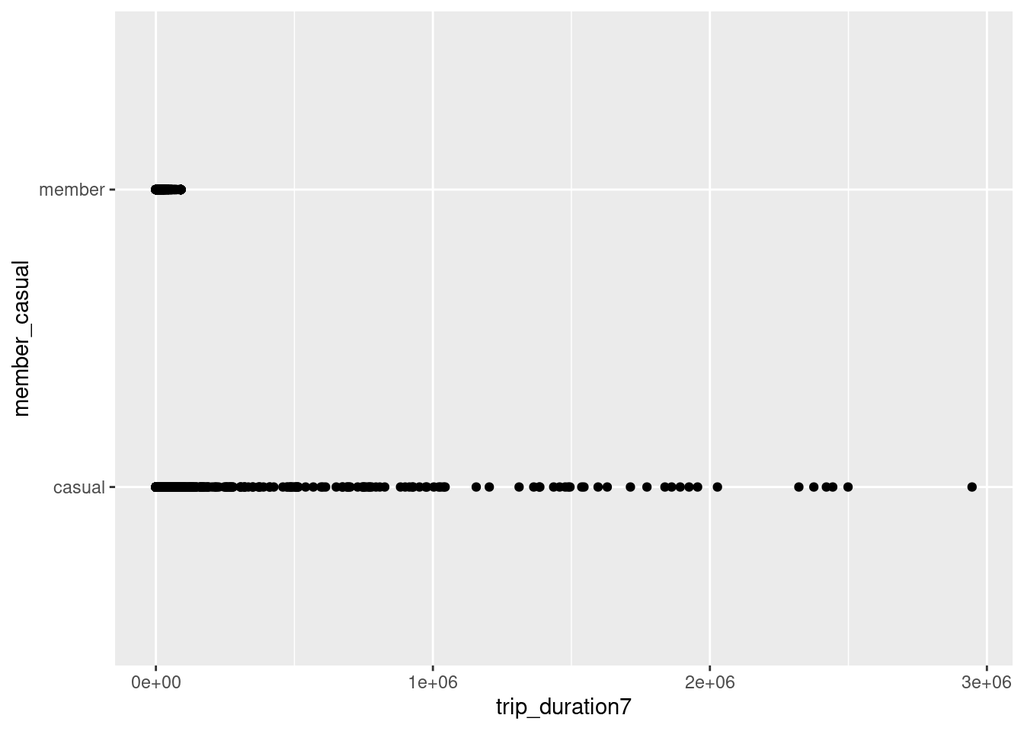

```r
ggplot(data = Jul_filtered, aes(x = trip_duration7, y = member_casual)) +
    geom_point()
```

#### Max Trip and Min Trip

Before filtering, the shortest trip by members was -12 seconds. Following are trips of -8 seconds,-5,-3,-1 and 32 trips of 0 seconds. For casual riders, the shortest trip was -8 seconds. Following are trips of -6, -5, four trips of -4 and a trip of -1 seconds.

The longest trip for members was 89997 seconds. The longest trip for casual riders is 2946429 seconds, or 4.87 weeks.

```r
Jul_c_trip_max <- (max(Jul_casual$trip_duration7))
Jul_m_trip_max <- (max(Jul_members$trip_duration7))
Jul_c_trip_min <- (min(Jul_casual$trip_duration7))
Jul_m_trip_min <- (min(Jul_members$trip_duration7))
```

#### Bike Type

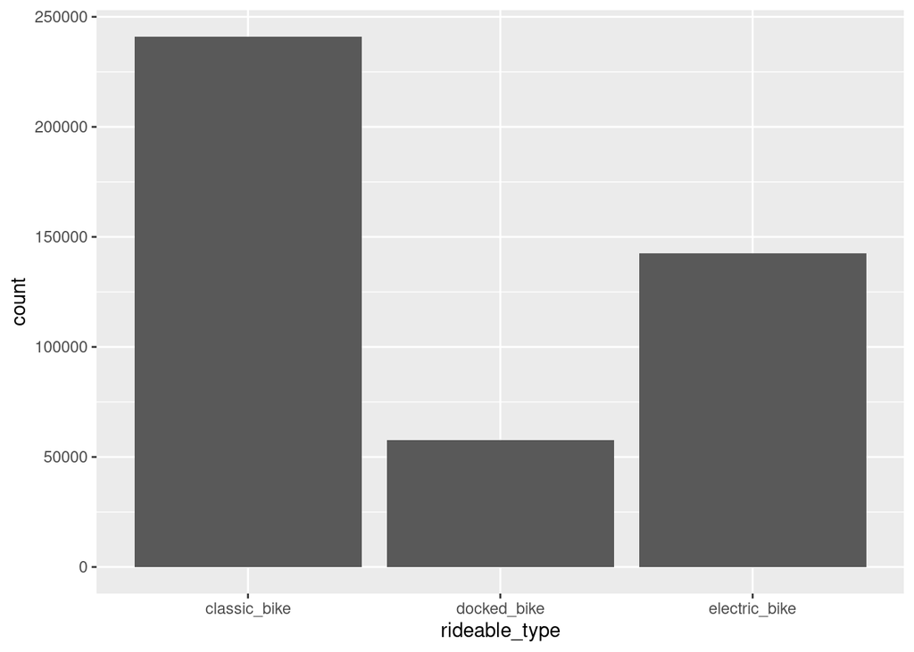

```r
Jul_c_elec <- length(which(Jul_casual$rideable_type == "electric_bike"))
Jul_c_classic <- length(which(Jul_casual$rideable_type == "classic_bike"))
Jul_c_docked <- length(which(Jul_casual$rideable_type == "docked_bike"))
ggplot(data = Jul_casual, aes(x = rideable_type)) +
     geom_bar()
```

Casual members took 241089 trips on classic bikes, 142639 trips on electric bikes, and 57640 trips on docked bikes.

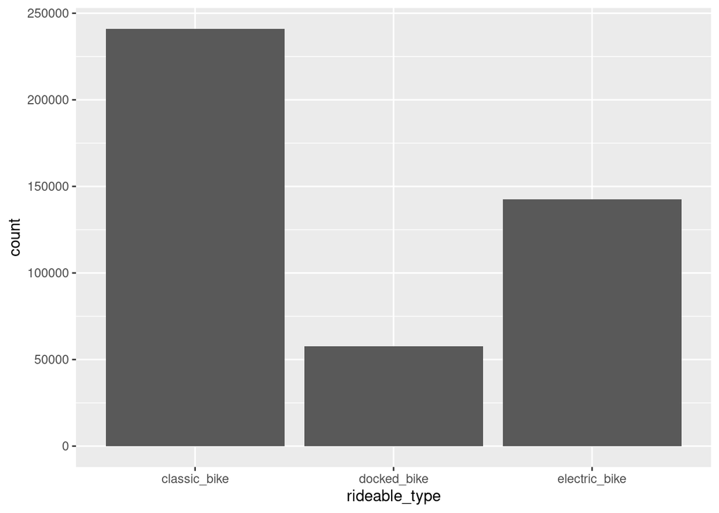

```r
Jul_m_elec <- length(which(Jul_members$rideable_type == "electric_bike"))
Jul_m_classic <- length(which(Jul_members$rideable_type == "classic_bike"))
Jul_m_docked <- length(which(Jul_members$rideable_type == "docked_bike"))
ggplot(data = Jul_casual, aes(x = rideable_type)) +
     geom_bar()
```